# Cardiovascular Disease Analysis

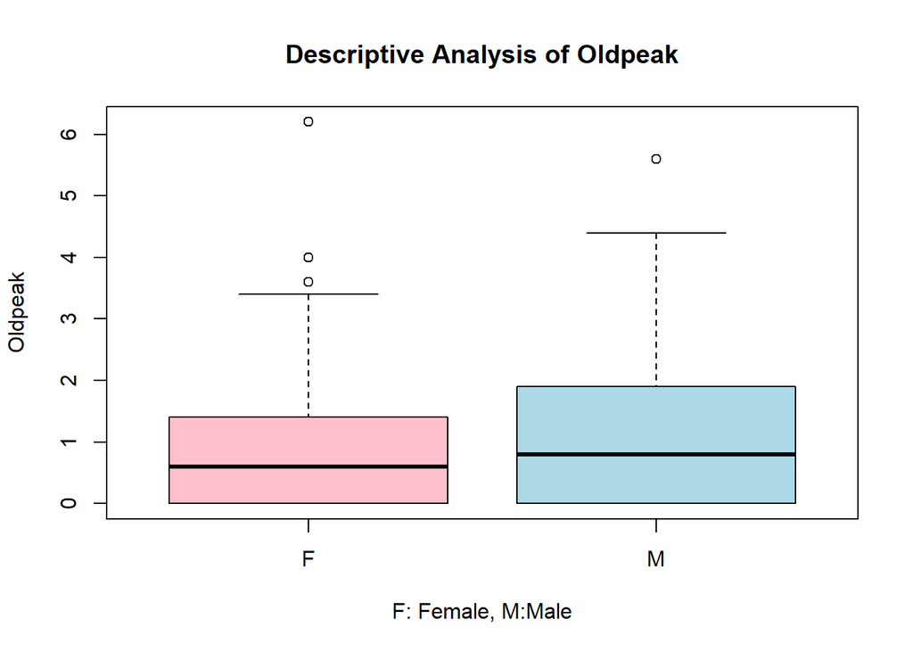

```r
boxplot(heart$oldpeak~heart$sex,main="Descriptive Analysis of Oldpeak",col=c("pink","lightblue"),xlab="F: Female, M:Male",ylab="Oldpeak")
```

In smooth curve between oldpeak and Heart attack we can see that there is a decreasing trend between them. In general on increasing oldpeak probability of heart attack is decreasing.

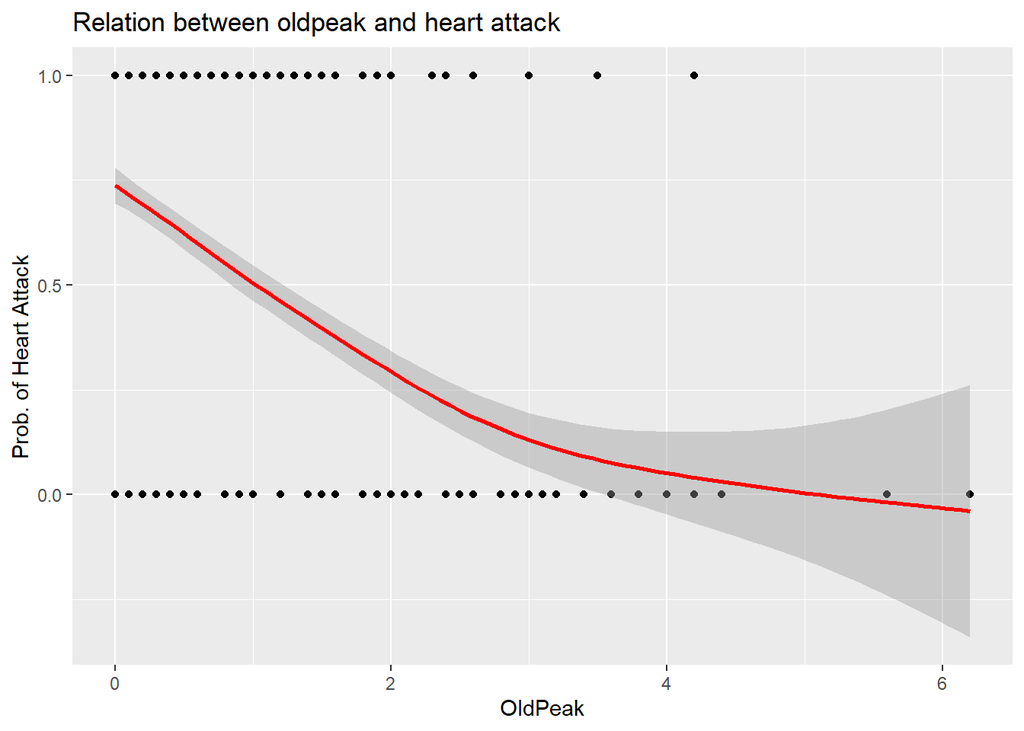

```r
ggplot(heart,aes(x=oldpeak,y=target))+geom_point()+geom_smooth(color="red")+
    scale_x_continuous(name="OldPeak")+
    scale_y_continuous(name="Prob. of Heart Attack")+
    ggtitle("Relation between oldpeak and heart attack")
```

# Slope Analysis

Slope of Peak Exercise: This is integer datatype with 3 categories 0,1 and 2.

```r
unique(heart$slope)
```

```
## [1] 2 0 1
```

In barplot we can see that population with slope 1 and 2 are nearly same and in maximum number.

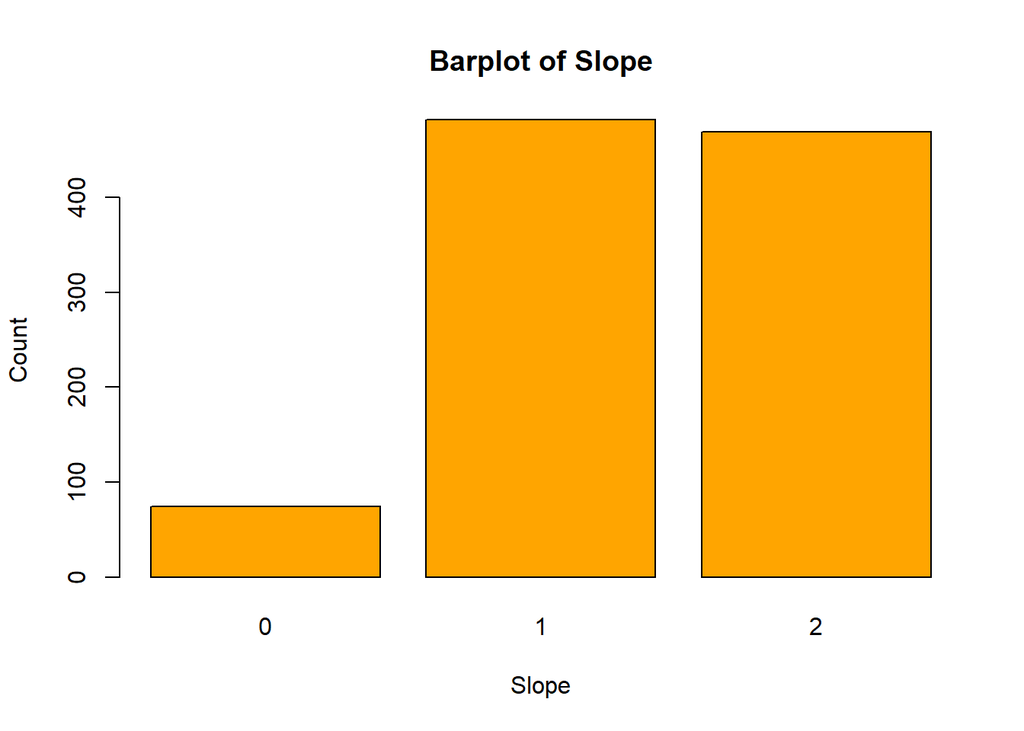

```r
l=table(heart$slope)
barplot(l,
       main="Barplot of Slope",
       xlab="Slope",
       ylab="Count",col="orange")
```

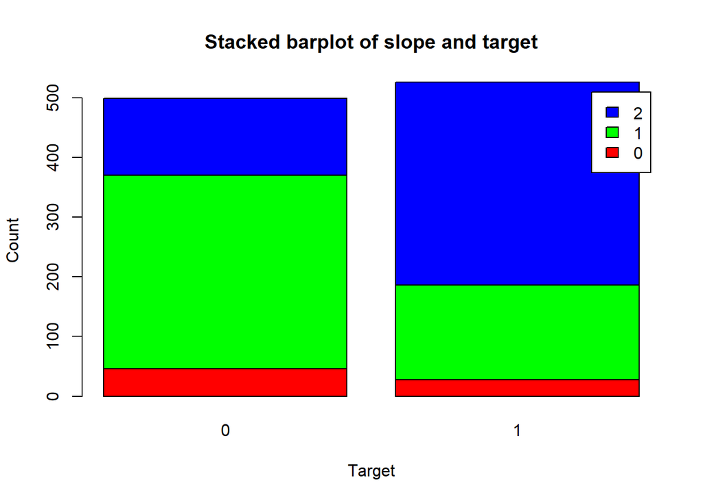

```r
m=table(heart$slope,heart$target)
barplot(m,
       main="Stacked barplot of slope and target",
       col=rainbow(3),
       xlab="Target",
       ylab="Count",legend=rownames(m))
```

In smooth curve between slope and target we can see that after unit 1 of slope with increase in slope, probability of heart attack is increasing.

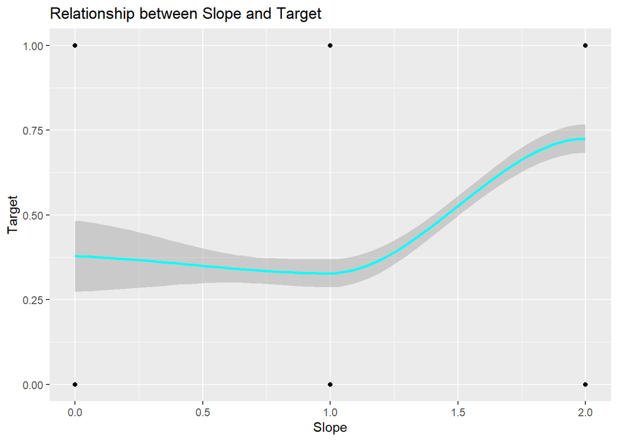

```r
ggplot(heart,aes(x=slope,y=target))+geom_point()+geom_smooth(method="loess",color="cyan")+
    scale_x_continuous(name="Slope")+
    scale_y_continuous(name="Target")+
    ggtitle("Relationship between Slope and Target")
```

# Ca Analysis

The Number of masor Vesseles: 0-4 colored by Flourosopy. In barplot we can see that, Most of population are with 0 ca category.

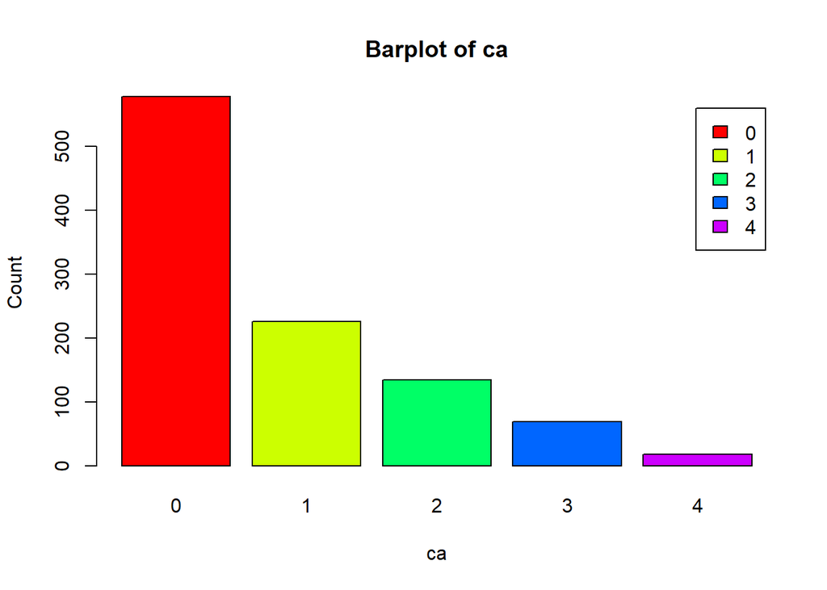

```r
n=table(heart$ca)
barplot(n,
       main="Barplot of ca",
       xlab="ca",
       col=rainbow(5),
       legend=rownames(n),
       ylab="Count")
```

By chance in stacked barplot between ca and target, we can see that people with ca category 0 are more likely to get heart attack.

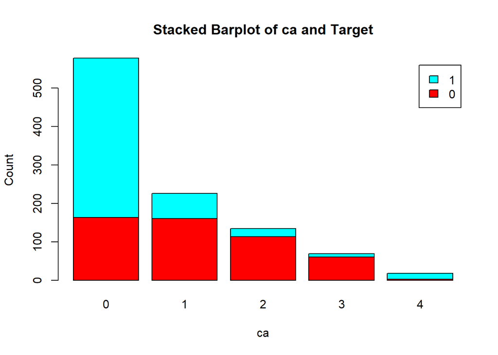

```r
o=table(heart$target,heart$ca)
barplot(o,
       main="Stacked Barplot of ca and Target",
       xlab="ca",
        col=rainbow(2),
       legend=rownames(o),
       ylab="Count")
```

In smooth curve between ca and target, we can see that there is local minima at ca category 2, First on increasing ca prob. of heart attack is decreasing again after local minima on increasing ca, prob of heart attack is increasing.

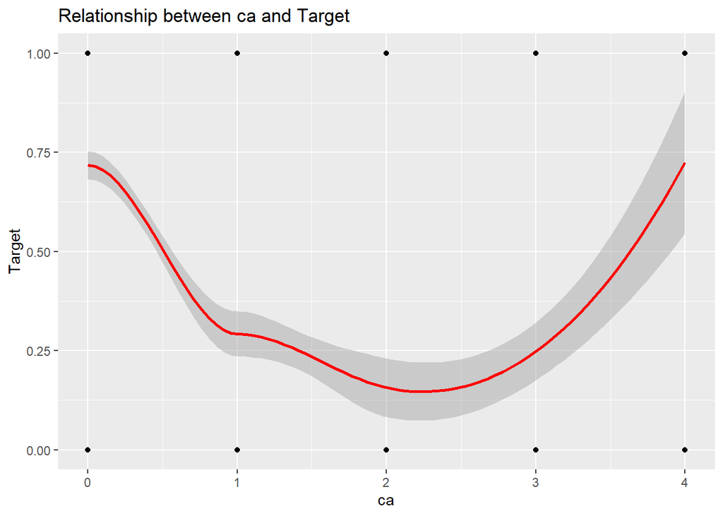

```r
ggplot(heart,aes(x=ca,y=target))+geom_point()+geom_smooth(method="loess",color="red")+
    scale_x_continuous(name="ca")+
    scale_y_continuous(name="Target")+
    ggtitle("Relationship between ca and Target")
```

# Test

### Chi-Squared Test

With this test we can verify if the variable target is dependent on age. We can see that p-value is less than 0.05, so target is depending on age.

```r
chisq.test(heart$age,heart$target)
```

```
##
##  Pearson's Chi-squared test
##
## data:  heart$age and heart$target
## X-squared = 178.77, df = 40, p-value < 2.2e-16
```

With Chi square test we can see how age and Hear Rate is correlating. We can see in chi square test between age and Heart Rate, P value is less than 0.05 so Heart Rate is depending on Age.

```r
chisq.test(heart$age,heart$thalach)
```

```
##
##  Pearson's Chi-squared test
##
## data:  heart$age and heart$thalach
## X-squared = 13443, df = 3600, p-value < 2.2e-16
```

### Shapiro-Wilk Test

Now, we want to determine if the variable chol (cholesterol), trestbps (blood pressure) and thalach (Heart rate) are normally distributed.

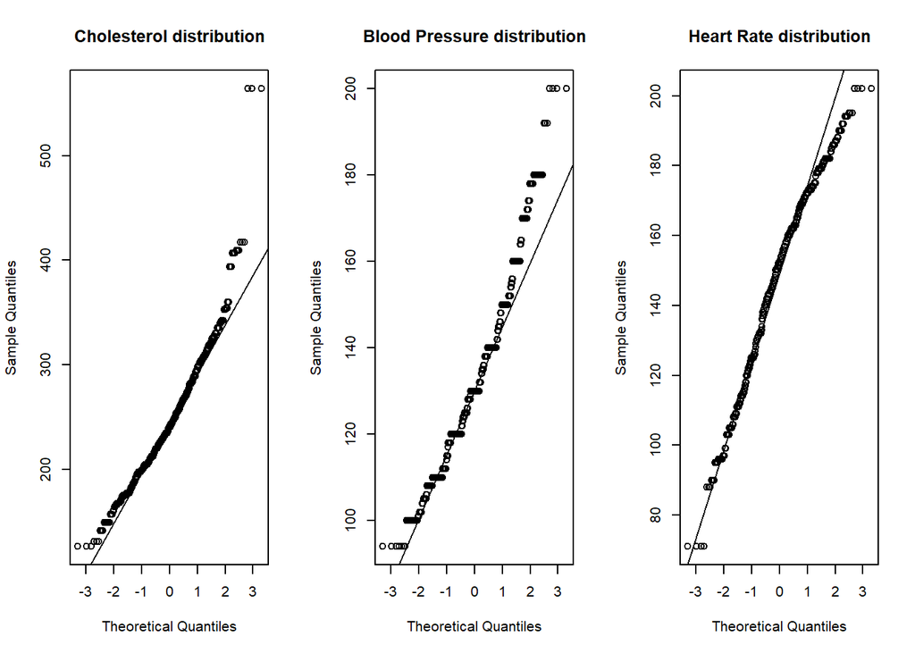

```r
par(mfrow=c(1,3))
qqnorm(heart$chol, main = "Cholesterol distribution")
qqline(heart$chol)
qqnorm(heart$trestbps, main ="Blood Pressure distribution")
qqline(heart$trestbps)
qqnorm(heart$thalach, main ="Heart Rate distribution")
qqline(heart$thalach)
```

From the normaly probability plot we can see that all variables differ from the normal distribution.

Now, with this test we can verify the null hypothesis.

```r
shapiro.test(heart$chol)
```

```
##
##  Shapiro-Wilk normality test
##
## data:  heart$chol
## W = 0.95022, p-value < 2.2e-16
```

```r
shapiro.test(heart$trestbps)
```

```
##
##  Shapiro-Wilk normality test
##
## data:  heart$trestbps
## W = 0.96331, p-value = 2.194e-15
```

```r
shapiro.test(heart$thalach)
```

```
##
##  Shapiro-Wilk normality test
##
## data:  heart$thalach
## W = 0.9774, p-value = 1.55e-11
```

In fact, the three tests carried out have a p value less than 5%, so we can reject the null hypothesis.

# Correlation

To avoid analyzing non-existent correlations, it was chosen to analyze only relationships that are believed to have an interesting relationship.

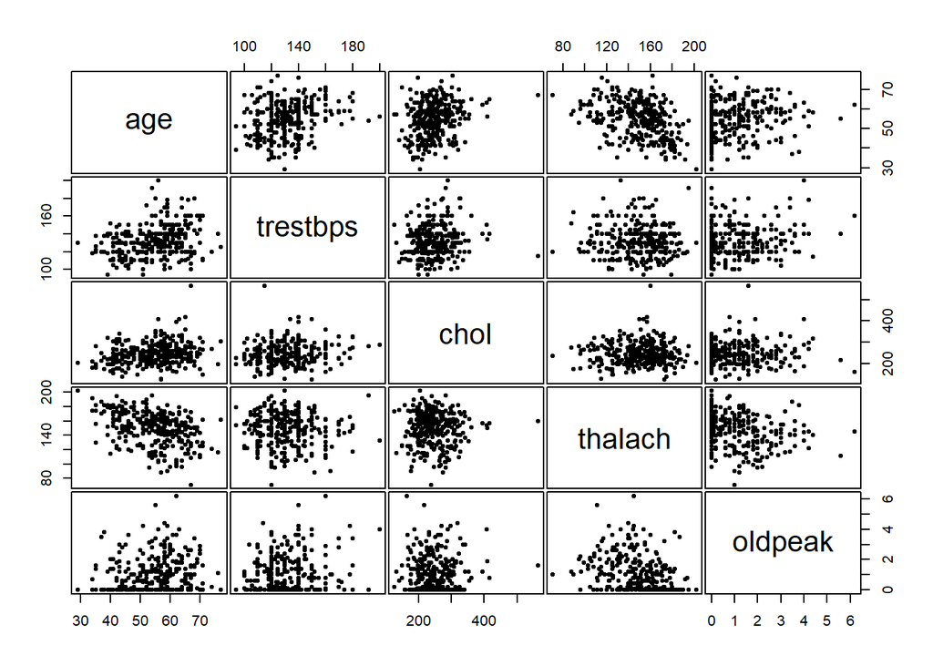

```r
pairs(heart[c(1,4,5,8,10)],pch=20,gap = 0.2)
```

```r
cor_heart=cor(heart[c(1,4,5,8,10)])
```

With this corrplot it is possible to see through the use of colors the correlations present between the chosen variables.

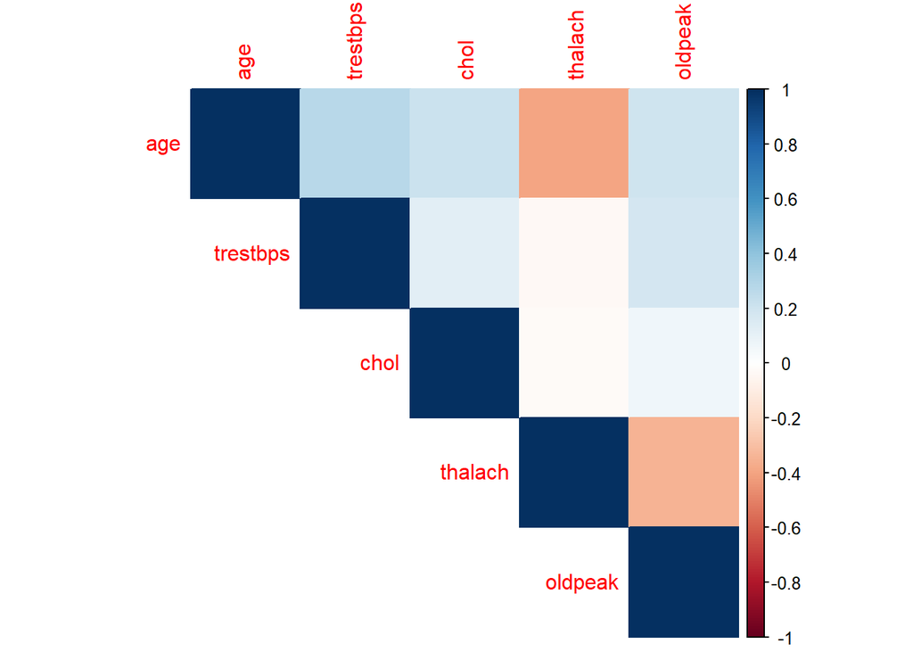

```r
corrplot(cor_heart, type="upper",method = "color")
```

# Linear Regression

### Age-Trestbps

```r
cor(heart$age,heart$trestbps)
```

```
## [1] 0.2711214
```

```r
lm_AT = lm (heart$age ~ heart$trestbps)
summary(lm_AT)
```

```
##
## Call:
## lm(formula = heart$age ~ heart$trestbps)
##
## Residuals:
##      Min       1Q   Median       3Q      Max
## -25.2078  -6.2078   0.7922   6.3197  23.4943
##
## Coefficients:
##                Estimate Std. Error t value Pr(>|t|)
## (Intercept)    35.95327    2.06943  17.373   <2e-16 ***
## heart$trestbps  0.14042    0.01559   9.009   <2e-16 ***
## ---
## Signif. codes:  0 '***' 0.001 '**' 0.01 '*' 0.05 '.' 0.1 ' ' 1
##
## Residual standard error: 8.737 on 1023 degrees of freedom
## Multiple R-squared:  0.07351,    Adjusted R-squared:  0.0726
## F-statistic: 81.16 on 1 and 1023 DF,  p-value: < 2.2e-16
```

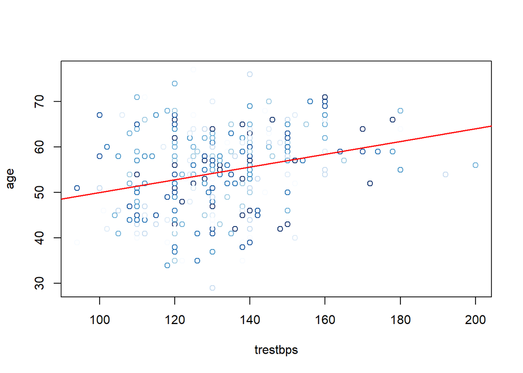

```r
plot(heart$age ~ heart$trestbps, xlab = "trestbps", ylab= "age", col = alpha(blues9))
abline(coef(lm_AT), col = "red", lwd=1.5)
```

It is therefore obtained that there is a relationship between age and rest blood pressure but the low value of the coefficient of determination R-squared does not fully/correctly explain the data, or that the variance of the residuals is very high.

### Age-Chol

```r
cor(heart$age,heart$chol)
```

```
## [1] 0.2198225
```

```r
lm_AC = lm (heart$age ~ heart$chol)
summary(lm_AC)
```

```
##
## Call:
## lm(formula = heart$age ~ heart$chol)
##
## Residuals:
##      Min       1Q   Median       3Q      Max
## -23.8106  -6.4005   0.4599   6.1894  23.4599
##
## Coefficients:
##              Estimate Std. Error t value Pr(>|t|)
## (Intercept) 44.925086   1.348065  33.326  < 2e-16 ***
## heart$chol   0.038655   0.005363   7.207 1.11e-12 ***
## ---
## Signif. codes:  0 '***' 0.001 '**' 0.01 '*' 0.05 '.' 0.1 ' ' 1
##
## Residual standard error: 8.855 on 1023 degrees of freedom
## Multiple R-squared:  0.04832,    Adjusted R-squared:  0.04739
## F-statistic: 51.94 on 1 and 1023 DF,  p-value: 1.108e-12
```

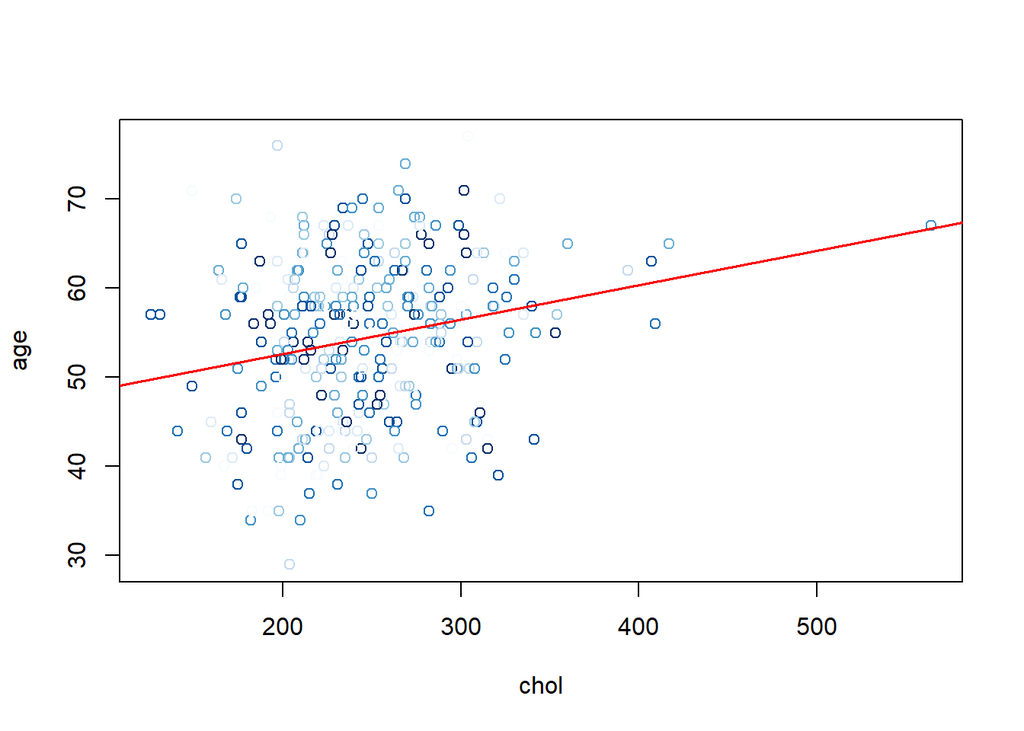

```r
plot(heart$age ~ heart$chol, xlab = "chol", ylab= "age", col = alpha(blues9))
abline(coef(lm_AC), col = "red", lwd=1.5)
```

Also in this case very similar results to the previous ones were obtained; in particular it can be noted that there is a correlation (even if it is low) between age and cholesterol value but the low value of the coefficient of determination R-squared does not fully/correctly explain the data.

### Age-Heart Rate

```r
cor(heart$age,heart$thalach)
```

```
## [1] -0.3902271
```

```r
lm_AHR = lm (heart$age ~ heart$thalach)
summary(lm_AHR)
```

```
##
## Call:
## lm(formula = heart$age ~ heart$thalach)
##
## Residuals:
##      Min       1Q   Median       3Q      Max
## -22.3755  -6.6071   0.6255   6.3954  24.5488
##
## Coefficients:
##               Estimate Std. Error t value Pr(>|t|)
## (Intercept)   77.38069    1.71274   45.18   <2e-16 ***
## heart$thalach -0.15389    0.01135  -13.56   <2e-16 ***
## ---
## Signif. codes:  0 '***' 0.001 '**' 0.01 '*' 0.05 '.' 0.1 ' ' 1
##
## Residual standard error: 8.357 on 1023 degrees of freedom
## Multiple R-squared:  0.1523, Adjusted R-squared:  0.1514
## F-statistic: 183.8 on 1 and 1023 DF,  p-value: < 2.2e-16
```

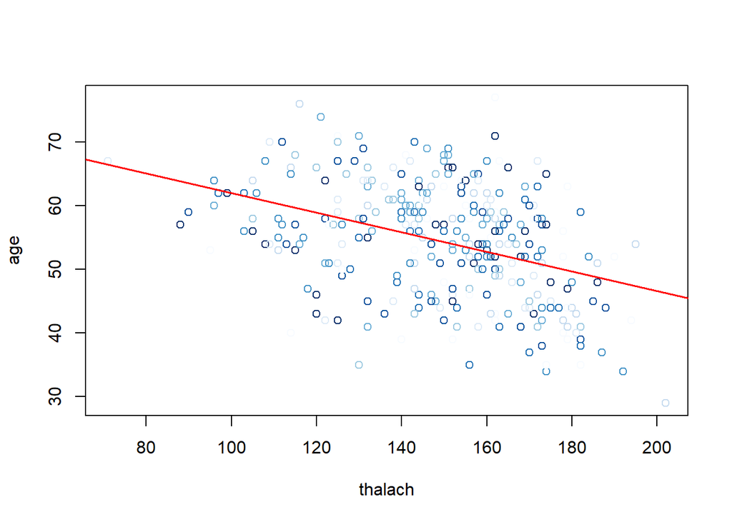

```r
plot(heart$age ~ heart$thalach, xlab = "thalach", ylab= "age", col = alpha(blues9))
abline(coef(lm_AHR), col = "red", lwd=1.5)
```

### Age-Oldpeak

```r
cor(heart$age,heart$oldpeak)
```

```
## [1] 0.2081367
```

```r
lm_AO = lm (heart$age ~ heart$oldpeak)
summary(lm_AO)
```

```
##
## Call:
## lm(formula = heart$age ~ heart$oldpeak)
##
## Residuals:
##      Min       1Q   Median       3Q      Max
## -23.7123  -6.3192   0.7166   6.2877  24.2877
##
## Coefficients:
##               Estimate Std. Error t value Pr(>|t|)
## (Intercept)    52.7123     0.3754 140.429  < 2e-16 ***
## heart$oldpeak   1.6070     0.2361   6.806  1.7e-11 ***
## ---
## Signif. codes:  0 '***' 0.001 '**' 0.01 '*' 0.05 '.' 0.1 ' ' 1
##
## Residual standard error: 8.878 on 1023 degrees of freedom
## Multiple R-squared:  0.04332,    Adjusted R-squared:  0.04239
## F-statistic: 46.32 on 1 and 1023 DF,  p-value: 1.705e-11
```

[figure not shown]

```r
plot(heart$age ~ heart$oldpeak, xlab = "age", ylab= "oldpeak", col = alpha(blues9))
abline(coef(lm_AO), col = "red", lwd=1.5)
```

### Chol-Trestbps

```r
cor(heart$chol,heart$trestbps)
```

```
## [1] 0.1279774
```

```r
lm_CT = lm (heart$chol ~ heart$trestbps)
summary(lm_CT)
```

```
##
## Call:
## lm(formula = heart$chol ~ heart$trestbps)
##
## Residuals:
##     Min      1Q  Median      3Q     Max
## -126.93  -33.47   -5.62   29.30  324.26
##
## Coefficients:
##                 Estimate Std. Error t value Pr(>|t|)
## (Intercept)    196.39085   12.12590  16.196  < 2e-16 ***
## heart$trestbps   0.37694    0.09133   4.127 3.97e-05 ***
## ---
## Signif. codes:  0 '***' 0.001 '**' 0.01 '*' 0.05 '.' 0.1 ' ' 1
##
## Residual standard error: 51.19 on 1023 degrees of freedom
## Multiple R-squared:  0.01638,    Adjusted R-squared:  0.01542
## F-statistic: 17.03 on 1 and 1023 DF,  p-value: 3.971e-05
```

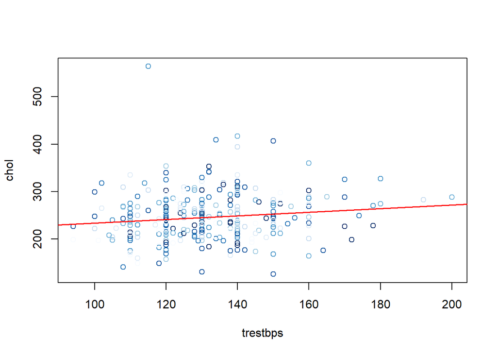

```r
plot(heart$chol ~ heart$trestbps, xlab = "trestbps", ylab= "chol", col = alpha(blues9))
abline(coef(lm_CT), col = "red", lwd=1.5)
```

### Chol-Heart Rate

```r
cor(heart$chol,heart$thalach)
```

```
## [1] -0.02177209
```

```r
lm_CHR = lm (heart$chol ~ heart$thalach)
summary(lm_CHR)
```

```
##
## Call:
## lm(formula = heart$chol ~ heart$thalach)
##
## Residuals:
##     Min      1Q  Median      3Q     Max
## -118.83  -34.84   -5.76   28.51  318.53
##
## Coefficients:
##                Estimate Std. Error t value Pr(>|t|)
## (Intercept)   253.28064   10.57626  23.948   <2e-16 ***
## heart$thalach  -0.04883    0.07010  -0.697    0.486
## ---
## Signif. codes:  0 '***' 0.001 '**' 0.01 '*' 0.05 '.' 0.1 ' ' 1
##
## Residual standard error: 51.61 on 1023 degrees of freedom
## Multiple R-squared:  0.000474,   Adjusted R-squared:  -0.000503
## F-statistic: 0.4852 on 1 and 1023 DF,  p-value: 0.4863
```

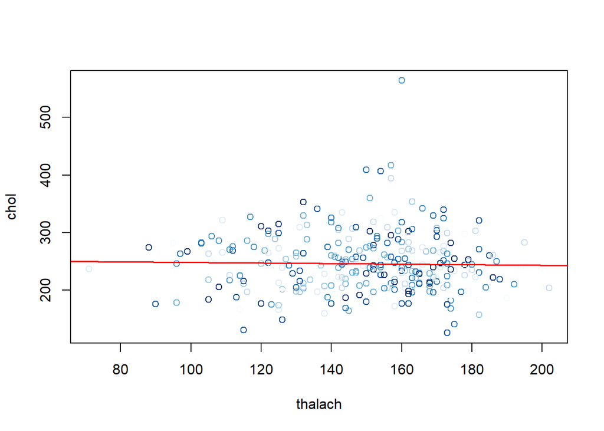

```r
plot(heart$chol ~ heart$thalach, xlab = "thalach", ylab= "chol", col = alpha(blues9))
abline(coef(lm_CHR), col = "red", lwd=1.5)
```

### Chol-Oldpeak

```r
cor(heart$chol,heart$oldpeak)
```

```
## [1] 0.06488031
```

```r
lm_CO = lm (heart$chol ~ heart$oldpeak)
summary(lm_CO)
```

```
##
## Call:
## lm(formula = heart$chol ~ heart$oldpeak)
##
## Residuals:
##     Min      1Q  Median      3Q     Max
## -117.52  -34.95   -5.51   31.08  316.49
##
## Coefficients:
##               Estimate Std. Error t value Pr(>|t|)
## (Intercept)    242.948      2.178  111.56   <2e-16 ***
## heart$oldpeak    2.849      1.370    2.08   0.0378 *
## ---
## Signif. codes:  0 '***' 0.001 '**' 0.01 '*' 0.05 '.' 0.1 ' ' 1
##
## Residual standard error: 51.51 on 1023 degrees of freedom
## Multiple R-squared:  0.004209,   Adjusted R-squared:  0.003236
## F-statistic: 4.324 on 1 and 1023 DF,  p-value: 0.03782
```

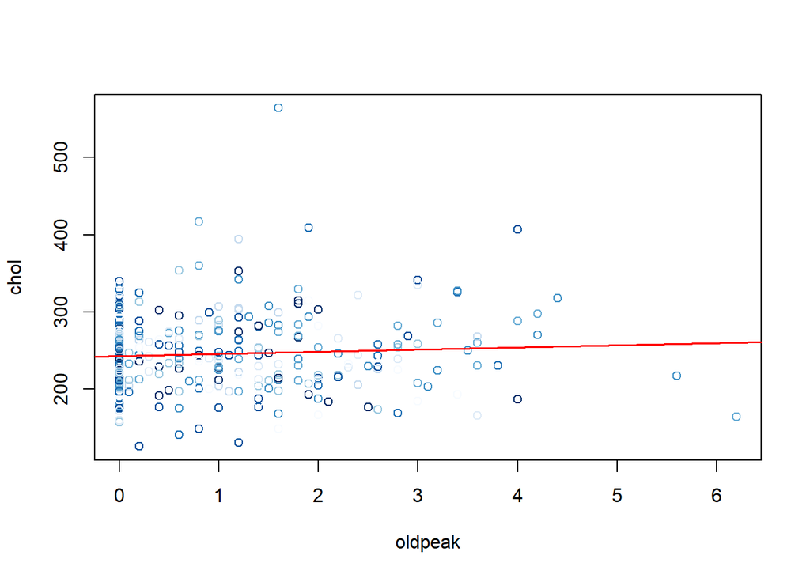

```r
plot(heart$chol ~ heart$oldpeak, xlab = "oldpeak", ylab= "chol", col = alpha(blues9))
abline(coef(lm_CO), col = "red", lwd=1.5)
```

### Trestbps-Heart Rate

```r
cor(heart$trestbps,heart$thalach)
```

```
## [1] -0.03926407
```

```r
lm_THR = lm (heart$trestbps ~ heart$thalach)
summary(lm_THR)
```

```
##
## Call:
## lm(formula = heart$trestbps ~ heart$thalach)
##
## Residuals:
##     Min      1Q  Median      3Q     Max
## -37.466 -11.765  -1.615   8.774  67.907
##
## Coefficients:
##                Estimate Std. Error t value Pr(>|t|)
## (Intercept)   136.06961    3.58894  37.914   <2e-16 ***
## heart$thalach  -0.02990    0.02379  -1.257    0.209
## ---
## Signif. codes:  0 '***' 0.001 '**' 0.01 '*' 0.05 '.' 0.1 ' ' 1
##
## Residual standard error: 17.51 on 1023 degrees of freedom
## Multiple R-squared:  0.001542,   Adjusted R-squared:  0.0005657
## F-statistic:  1.58 on 1 and 1023 DF,  p-value: 0.2091
```

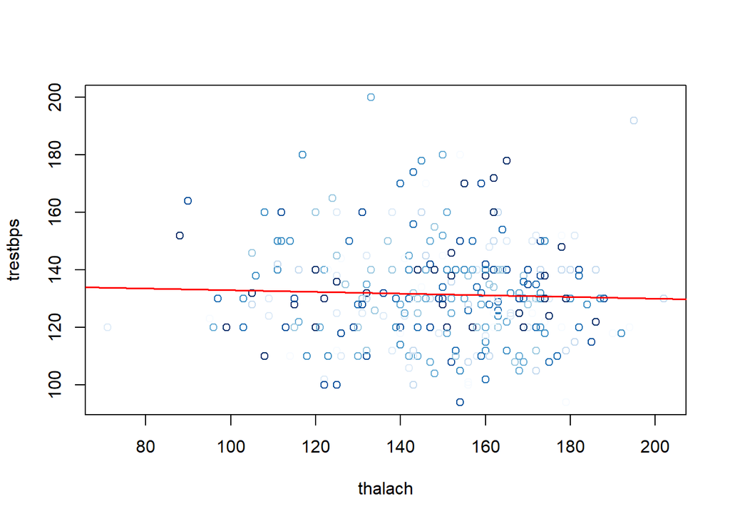

```r
plot(heart$trestbps ~ heart$thalach, xlab = "thalach", ylab= "trestbps", col = alpha(blues9))
abline(coef(lm_THR), col = "red", lwd=1.5)
```

### Trestbps-Oldpeak

```r
cor(heart$trestbps,heart$oldpeak)
```

```
## [1] 0.1874341
```

```r
lm_TO = lm (heart$trestbps ~ heart$oldpeak)
summary(lm_TO)
```

```
##
## Call:
## lm(formula = heart$trestbps ~ heart$oldpeak)
##
## Residuals:
##     Min      1Q  Median      3Q     Max
## -34.618 -11.441  -1.177   9.382  63.382
##
## Coefficients:
##               Estimate Std. Error t value Pr(>|t|)
## (Intercept)   128.6178     0.7278 176.710  < 2e-16 ***
## heart$oldpeak   2.7941     0.4578   6.103 1.47e-09 ***
## ---
## Signif. codes:  0 '***' 0.001 '**' 0.01 '*' 0.05 '.' 0.1 ' ' 1
##
## Residual standard error: 17.21 on 1023 degrees of freedom
## Multiple R-squared:  0.03513,    Adjusted R-squared:  0.03419
## F-statistic: 37.25 on 1 and 1023 DF,  p-value: 1.474e-09
```

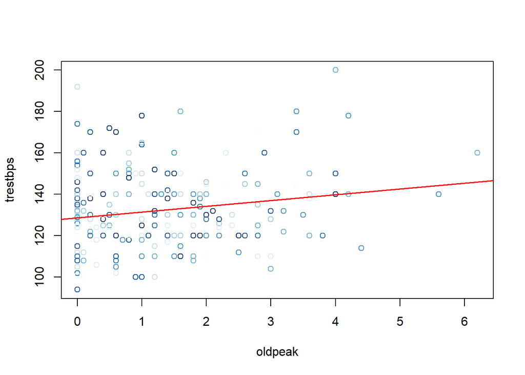

```r
plot(heart$trestbps ~ heart$oldpeak, xlab = "oldpeak", ylab= "trestbps", col = alpha(blues9))
abline(coef(lm_TO), col = "red", lwd=1.5)
```

### Oldpeak-Heart Rate

```r
cor(heart$oldpeak,heart$thalach)
```

```
## [1] -0.3497962
```

```r
lm_OT = lm (heart$oldpeak ~ heart$thalach)
summary(lm_OT)
```

```
##
## Call:
## lm(formula = heart$oldpeak ~ heart$thalach)
##
## Residuals:
##     Min      1Q  Median      3Q     Max
## -2.0205 -0.7877 -0.3410  0.5870  5.0550
##
## Coefficients:
##                Estimate Std. Error t value Pr(>|t|)
## (Intercept)    3.735643   0.225717   16.55   <2e-16 ***
## heart$thalach -0.017866   0.001496  -11.94   <2e-16 ***
## ---
## Signif. codes:  0 '***' 0.001 '**' 0.01 '*' 0.05 '.' 0.1 ' ' 1
##
## Residual standard error: 1.101 on 1023 degrees of freedom
## Multiple R-squared:  0.1224, Adjusted R-squared:  0.1215
## F-statistic: 142.6 on 1 and 1023 DF,  p-value: < 2.2e-16
```

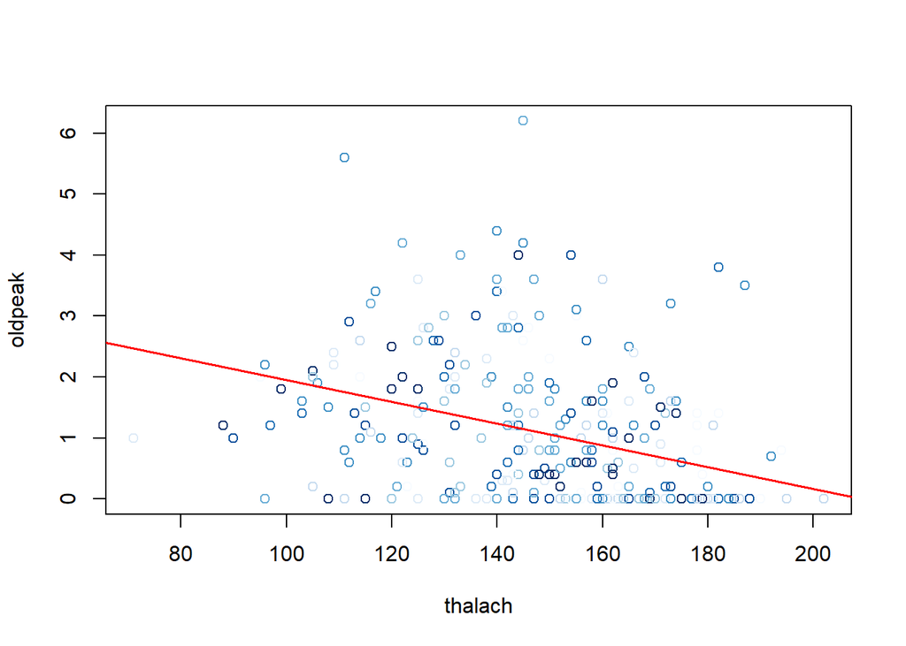

```r
plot(heart$oldpeak ~ heart$thalach, xlab = "thalach", ylab= "oldpeak", col = alpha(blues9))
abline(coef(lm_OT), col = "red", lwd=1.5)
```

In conclusion, after having analyzed the correlations and the linear regression model, we can state that satisfactory results have not been obtained, as most of the results obtained have certainly been lower than expected.

# Residuals

Residual plots are used to look for underlying patterns in the residuals that may mean that the model has a problem. Now, we will will be analysed only the regression model between age and cholesterol.

When we look at the first plot, we see that the data does not have any obvious distinct pattern. While it is slightly curved, it has equally spread residuals around the horizontal line without a distinct pattern. This is a good indication it is not a non-linear relationship.

In the second plot residuals should be normally distributed and the Q-Q Plot will show this. If residuals follow close to a straight line on this plot, it is a good indication they are normally distributed. For our model, the Q-Q plot shows pretty good alignment to the the line with a few points at the top slightly offset. Probably not significant and a reasonable alignment.

In the third plot test the linear regression assumption of equal variance (homoscedasticity) i.e. that the residuals have equal variance along the regression line. It is also called the Spread-Location plot. In our case the residuals do not have constant variance and the line is clearnly not horizontal.

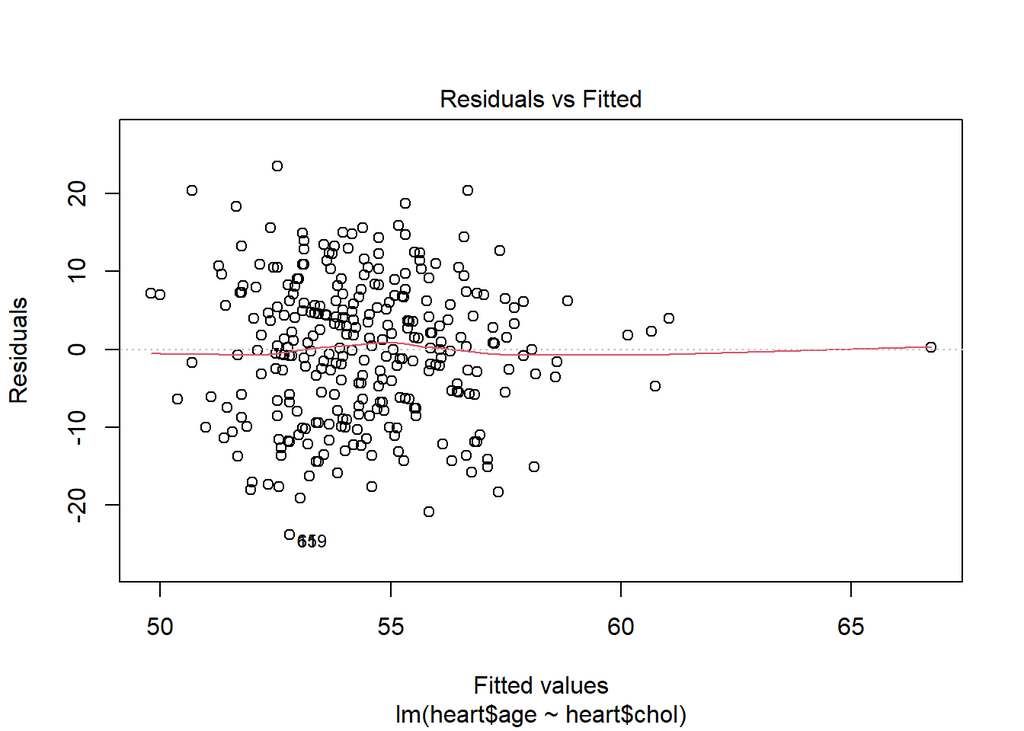

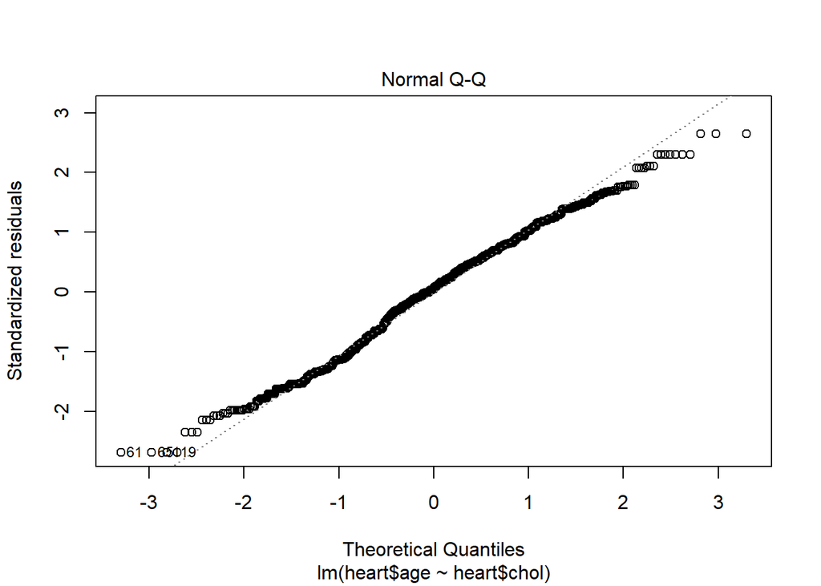

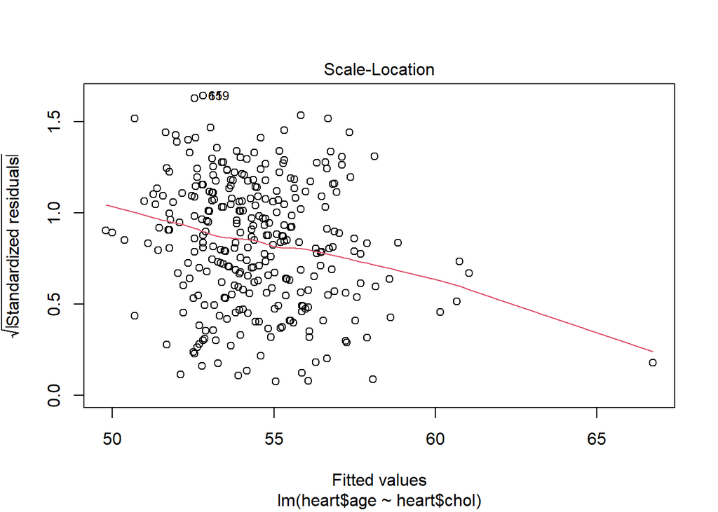

```r
plot(lm_AC, which=c(1,2,3), caption= list("Residuals vs Fitted", "Normal Q-Q","Scale-Location"),qqline= TRUE, col="black")
```

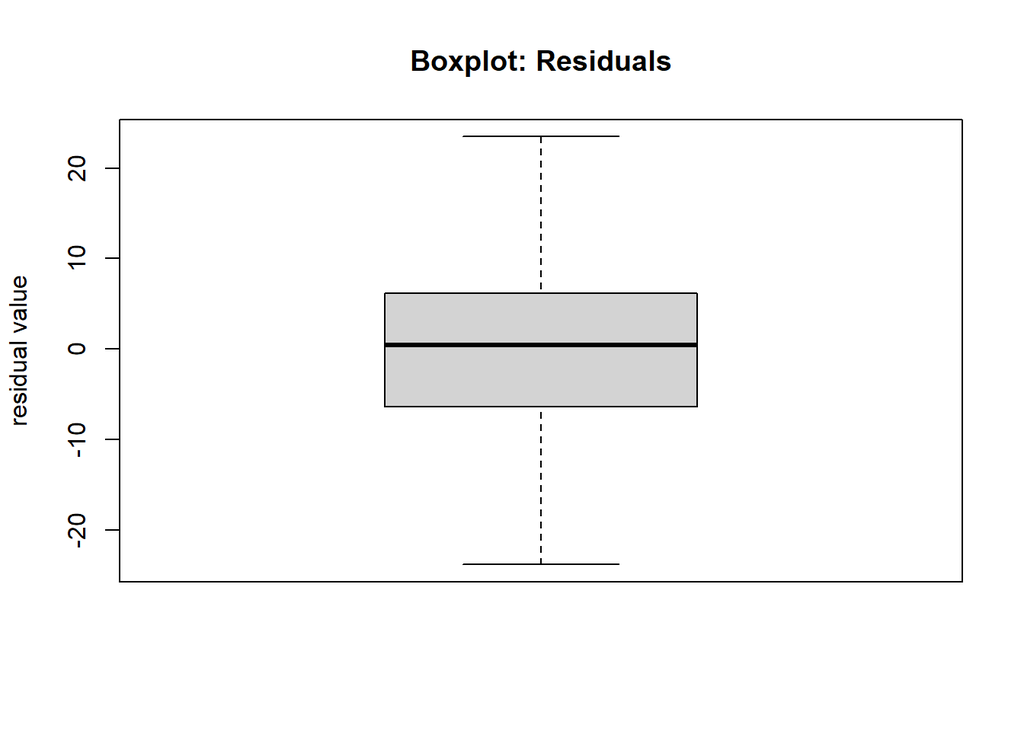

```r
boxplot(lm_AC[['residuals']],main='Boxplot: Residuals',ylab='residual value')
```